# Exam

### Part vii

Find the best performing of the selected subset models as measured by adjusted R-squared. Which predictors are not included in this model?

1 mark

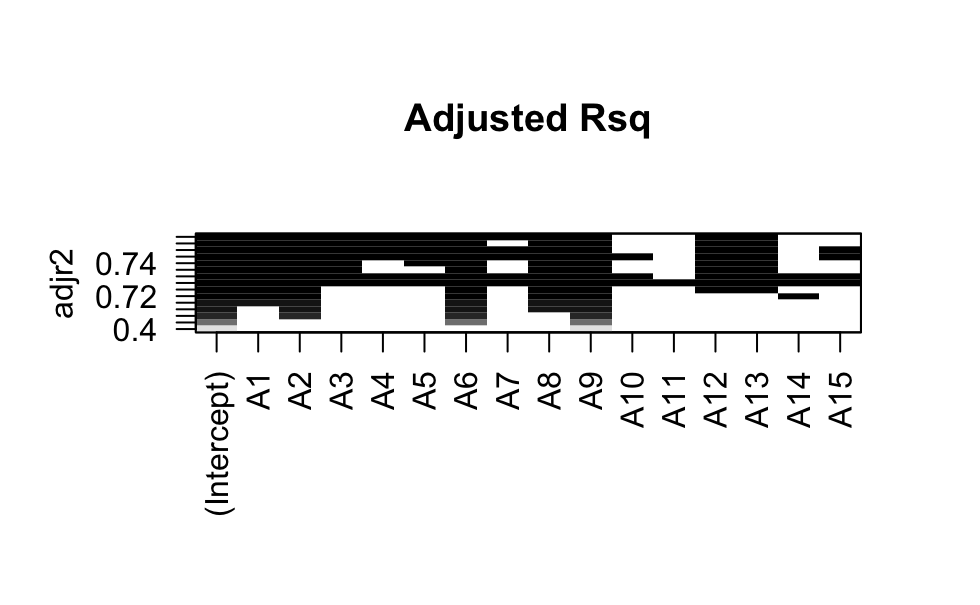

```r
plot(regsubsets_out, scale='adjr2', main='Adjusted Rsq')
```

A10, A11, A14, A15

### Part viii

Is the best performing model from such a search the best model possible we can construct? Explain your answer.

2 marks

No. we should compare different methods such as stepwise selection to preict the best model.

### Part ix

Make a plot to show how adjusted R-squared varies against number of predictors for the best subsets identified. Label your plot axes appropriately.

Hint: You can find the set of adjusted R-squared values by using the summary command on the output of the `regsubsets` command via `summary(...)$adjr2`.

3 marks

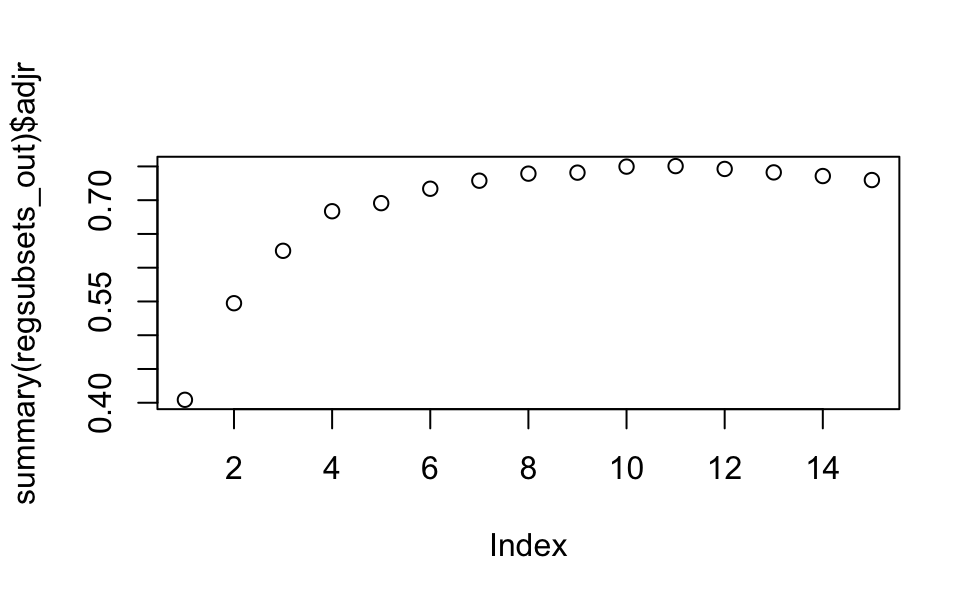

```r
plot(summary(regsubsets_out)$adjr)
```